# SVM_Behavioral data

```python
import pandas as pd
import matplotlib.pyplot as plt
import seaborn as sns
import numpy as np
```

```python
import warnings
pd.set_option('display.float_format', '{:.10f}'.format)
warnings.filterwarnings('ignore')
```

```python
df=pd.read_csv("personality_dataset.csv")
#https://www.kaggle.com/datasets/rakeshkapilavai/extrovert-vs-introvert-behavior-data
```

```python
df.shape,df.columns,df.dtypes
```

```
((2900, 8),
 Index(['Time_spent_Alone', 'Stage_fear', 'Social_event_attendance',
        'Going_outside', 'Drained_after_socializing', 'Friends_circle_size',
        'Post_frequency', 'Personality'],
       dtype='object'),
 Time_spent_Alone             float64
 Stage_fear                    object
 Social_event_attendance      float64
 Going_outside                float64
 Drained_after_socializing     object
 Friends_circle_size          float64
 Post_frequency               float64
 Personality                   object
 dtype: object)
```

```python
df.isnull().sum()
```

```
Time_spent_Alone             63
Stage_fear                   73
Social_event_attendance      62
Going_outside                66
Drained_after_socializing    52
Friends_circle_size          77
Post_frequency               65
Personality                   0
dtype: int64
```

There are missing values. In order to fill them we will use the mode since the above variables are either categorical or represent a scale

```python
for i in df.columns:
    df[i].fillna(df[i].mode()[0],inplace=True)
```

```python
df.isnull().sum()
```

```
Time_spent_Alone             0
Stage_fear                   0
Social_event_attendance      0
Going_outside                0
Drained_after_socializing    0
Friends_circle_size          0
Post_frequency               0
Personality                  0
dtype: int64
```

Missing values have been filled

# SVM Classification

Images taken from https://www.geeksforgeeks.org/machine-learning/support-vector-machine-algorithm/

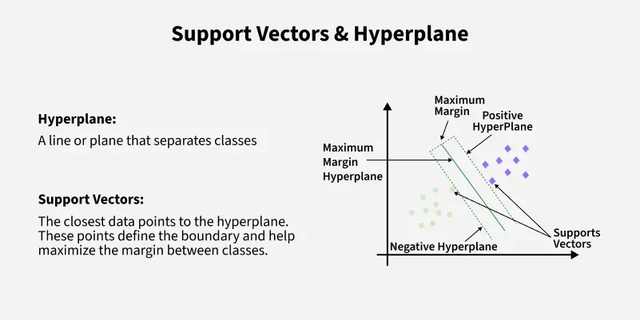

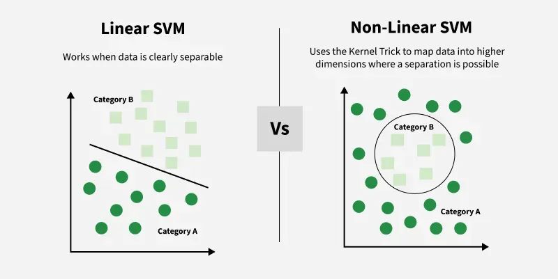

[figure not shown]

### SVM hyperparameters

The C parameter

The C parameter is inversely proportional to the margin size, this means that the larger the value of C, the smaller the margin, and, conversely, the smaller the value of C, the larger the margin. The C parameter can be used along with any kernel, it tells the algorithm how much to avoid misclassifying each training sample, due to that, it is also known as regularization.

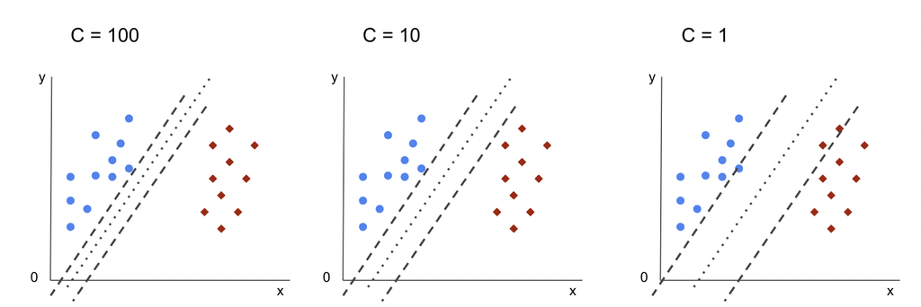

The gamma hyperparameter The gamma hyperparameter ,like C, is somewhat inversely proportional to its distance. The higher its value, the closest are the points that are considered for the decision boundary, and the lowest the gamma, the farther points are also considered for choosing the decision boundary.

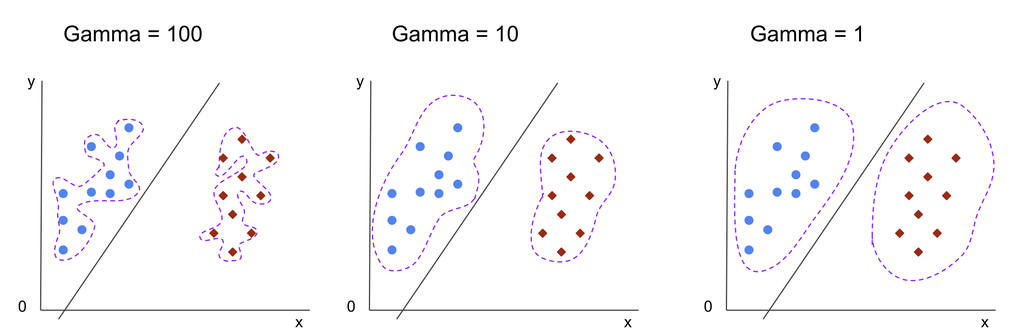

Source:https://stackabuse.com/understanding-svm-hyperparameters/

# Data preparation for SVM classification

```python
from sklearn.preprocessing import LabelEncoder
```

```python
le=LabelEncoder()
y=le.fit_transform(df["Personality"])
#0=Extrovert
le.classes_
```

```
array(['Extrovert', 'Introvert'], dtype=object)
```

```python
y.mean()
```

```
0.48586206896551726
```

The classes are balanced

```python
from sklearn.model_selection import train_test_split
```

```python
X=df.drop("Personality",axis=1)
```

```python
dummies=pd.get_dummies(df[["Stage_fear","Drained_after_socializing"]])
```

```python
X=X.drop(["Stage_fear","Drained_after_socializing"],axis=1)
X=pd.concat([X,dummies],axis=1)
```

```python
X.columns
dummies.columns
```

```
Index(['Stage_fear_No', 'Stage_fear_Yes', 'Drained_after_socializing_No',
       'Drained_after_socializing_Yes'],
      dtype='object')
```

Furthermore we need to scale the rest of the features since their scales are different

```python
from sklearn.preprocessing import MinMaxScaler
```

[output not shown]

```python
X[["Time_spent_Alone","Social_event_attendance","Going_outside","Friends_circle_size","Post_frequency"]
  ]=MinMaxScaler().fit_transform(X[["Time_spent_Alone","Social_event_attendance","Going_outside","Friends_circle_size","Post_frequency"]
  ])
```

```python
X_train,X_test,y_train,y_test=train_test_split(X,y)
```

```python
from sklearn.svm import SVC
from sklearn.metrics import accuracy_score
```

```python
model_linear=SVC(kernel="linear")
```

```python
model_linear.fit(X_train,y_train)
```

```
SVC(kernel='linear')
```

```python
y_pred=model_linear.predict(X_test)
```

```python
accuracy_score(y_test,y_pred)
```

```
0.9241379310344827
```

```python
from sklearn.metrics import confusion_matrix,classification_report
```

```python
confusion_matrix(y_test,y_pred)
```

```
array([[335,  26],
       [ 29, 335]], dtype=int64)
```

```python
print(classification_report(y_test,y_pred))
#Precision = TP/(TP+FP) -> useful when we want to minimize irrelevant items incorrectly clasified as positive
#Recall=TP/(TP+FN)-->Useful when we want to minimize the number of relevant items missed by the model
#Since our dataset is balanced we focus on accuracy
```

```
              precision    recall  f1-score   support

           0       0.92      0.93      0.92       361
           1       0.93      0.92      0.92       364

    accuracy                           0.92       725
   macro avg       0.92      0.92      0.92       725
weighted avg       0.92      0.92      0.92       725
```

```python
model_rbf=SVC(kernel="rbf")
```

```python
model_rbf.fit(X_train,y_train)
```

```
SVC()
```

```python
y_pred=model_rbf.predict(X_test)
```

```python
confusion_matrix(y_test,y_pred)
```

```
array([[335,  26],
       [ 17, 347]], dtype=int64)
```

```python
print(classification_report(y_test,y_pred))
```

```
              precision    recall  f1-score   support

           0       0.95      0.93      0.94       361
           1       0.93      0.95      0.94       364

    accuracy                           0.94       725
   macro avg       0.94      0.94      0.94       725
weighted avg       0.94      0.94      0.94       725
```

The rbf kernel gives us a higher accuracy Furhermore we will perform cross validation for both models

```python
from sklearn.model_selection import cross_val_score
```

```python
print(cross_val_score(model_linear, X, y, cv=5))
print("\n",cross_val_score(model_linear, X, y, cv=5).mean())
```

```
[0.96551724 0.92758621 0.91724138 0.89137931 0.88793103]

 0.9179310344827586
```

```python
print(cross_val_score(model_rbf, X, y, cv=5))
print("\n",cross_val_score(model_rbf, X, y, cv=5).mean())
```

```
[0.97241379 0.93793103 0.92758621 0.91551724 0.91724138]

 0.9341379310344827
```

# Hyperparameter tuning

```python
from sklearn.model_selection import GridSearchCV
```

```python
#Define grid
param_grid={
    "C":[0.01,0.1,0.5,1],
    "kernel":["linear","rbf"],
    "gamma":["scale",1,10,100]
}
```

```python
grid=GridSearchCV(SVC(),param_grid,cv=5,scoring="accuracy",n_jobs=-1)
```

```python
grid.fit(X_train,y_train)
```

```
GridSearchCV(cv=5, estimator=SVC(), n_jobs=-1,
             param_grid={'C': [0.01, 0.1, 0.5, 1],
                         'gamma': ['scale', 1, 10, 100],
                         'kernel': ['linear', 'rbf']},
             scoring='accuracy')
```

```python
print("Best parameters:", grid.best_params_)
print("Best CV accuracy:", grid.best_score_)
```

```
Best parameters: {'C': 0.01, 'gamma': 'scale', 'kernel': 'rbf'}
Best CV accuracy: 0.9319540229885057
```

```python
y_pred=grid.predict(X_test)
print(accuracy_score(y_test,y_pred))
```

```
0.9406896551724138
```